# CNN

Convolutional Neural Networks (CNN) CNNs are a class of deep neural networks commonly used for analyzing visual imagery. They are specifically designed to process data with a grid-like topology, such as images. Key Components of CNNs Convolutional Layers: Apply a set of filters (kernels) to the input image. Perform convolution operations to extract features. Preserve spatial relationships by learning image features using small squares of input data. Output a set of feature maps. Activation Function: Typically use ReLU (Rectified Linear Unit) to introduce non-linearity. Helps the network learn complex patterns. Pooling Layers: Reduce the spatial dimensions of the feature maps. Perform down-sampling using operations like max pooling. Reduce computational load and control overfitting. Flattening: Converts the 2D feature maps into a 1D feature vector. Prepares the data for the fully connected layers. Fully Connected (Dense) Layers: Perform high-level reasoning using the features extracted by convolutional layers. Combine features to predict the final output classes. Output Layer: Uses a softmax activation function for multi-class classification. Outputs probabilities for each class. Benefits of CNNs Parameter Sharing: Reduces the number of parameters, making the network easier to train and less prone to overfitting. Local Connectivity: Ensures that the model learns spatial hierarchies of features. Translation Invariance: Recognizes objects in images regardless of their position. Applications Image Classification: Assigning a label to an entire image. Object Detection: Identifying objects within an image and their locations. Segmentation: Partitioning an image into segments to highlight areas of interest. Other Domains: Also used in audio processing, natural language processing, and video analysis.

```python
# only for cuda enabled laptop and desktop
import tensorflow as tf
physical_devices = tf.config.experimental.list_physical_devices('GPU')
print(physical_devices)
if physical_devices:
  tf.config.experimental.set_memory_growth(physical_devices[0], True)
```

```
[PhysicalDevice(name='/physical_device:GPU:0', device_type='GPU')]
```

```python
import tensorflow as tf
import numpy as np
import matplotlib.pyplot as plt
import seaborn as sns
from tensorflow.keras import datasets, layers, models
sns.set_style('whitegrid')
```

```python
(train_images,train_labels), (test_images,test_labels) = datasets.cifar10.load_data()
```

```python
test_images.shape
```

```
(10000, 32, 32, 3)
```

```python
train_images.shape
```

```
(50000, 32, 32, 3)
```

```python
train_images[0]
```

```
array([[[ 59,  62,  63],
        [ 43,  46,  45],
        [ 50,  48,  43],
        ...,
        [158, 132, 108],
        [152, 125, 102],
        [148, 124, 103]],

       [[ 16,  20,  20],
        [  0,   0,   0],
        [ 18,   8,   0],
        ...,
        [123,  88,  55],
        [119,  83,  50],
        [122,  87,  57]],

       [[ 25,  24,  21],
        [ 16,   7,   0],
        [ 49,  27,   8],
        ...,
        [118,  84,  50],
        [120,  84,  50],
        [109,  73,  42]],

       ...,

       [[208, 170,  96],
        [201, 153,  34],
        [198, 161,  26],
        ...,
        [160, 133,  70],
        [ 56,  31,   7],
        [ 53,  34,  20]],

       [[180, 139,  96],
        [173, 123,  42],
        [186, 144,  30],
        ...,
        [184, 148,  94],
        [ 97,  62,  34],
        [ 83,  53,  34]],

       [[177, 144, 116],
        [168, 129,  94],
        [179, 142,  87],
        ...,
        [216, 184, 140],
        [151, 118,  84],
        [123,  92,  72]]], dtype=uint8)
```

```python
train_images[0].shape
```

```
(32, 32, 3)
```

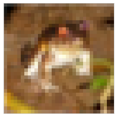

```python
plt.imshow(train_images[0])
plt.xticks([])
plt.yticks([])
plt.grid(False)
plt.show()
```

```python
train_labels[0]
```

```
array([6], dtype=uint8)
```

```python
train_labels[0][0]
```

```
6
```

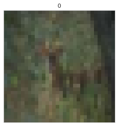

```python
plt.imshow(train_images[10])
plt.title(test_labels[10][0])
plt.xticks([])
plt.yticks([])
plt.grid(False)
plt.show()
```

```python
class_names = ['airplane','automobile','bird','cat','deer','dog','frog','horse','ship','truck']
```

```python
class_names[train_labels[0][0]]
```

```
'frog'
```

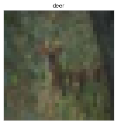

```python
plt.imshow(train_images[10])
plt.title(class_names[train_labels[10][0]])
plt.xticks([])
plt.yticks([])
plt.grid(False)
plt.show()
```

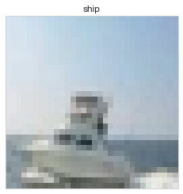

```python
plt.imshow(train_images[100])
plt.title(class_names[train_labels[100][0]])
plt.xticks([])
plt.yticks([])
plt.grid(False)
plt.show()
```

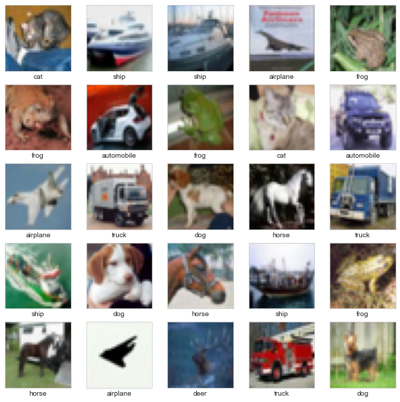

```python
plt.figure(figsize=(10,10))
for i in range(25):
    plt.subplot(5,5,i+1)
    plt.xticks([])
    plt.yticks([])
    plt.grid(False)
    plt.imshow(test_images[i], cmap=plt.cm.binary)
    plt.xlabel(class_names[test_labels[i][0]])
plt.show()
```

```python
train_images,test_images = train_images / 255.0, test_images / 255.0
```

```python
model = models.Sequential()
model.add(layers.Conv2D(32,(3,3),activation='relu',input_shape=(32,32,3)))
model.add(layers.MaxPooling2D((2,2)))
model.add(layers.Conv2D(64,(3,3),activation='relu'))
model.add(layers.MaxPool2D((2,2)))
model.add(layers.Conv2D(64,(3,3),activation='relu'))
model.summary()
```

```
Model: "sequential"
_________________________________________________________________
Layer (type)                 Output Shape              Param #
=================================================================
conv2d (Conv2D)              (None, 30, 30, 32)        896
_________________________________________________________________
max_pooling2d (MaxPooling2D) (None, 15, 15, 32)        0
_________________________________________________________________
conv2d_1 (Conv2D)            (None, 13, 13, 64)        18496
_________________________________________________________________
max_pooling2d_1 (MaxPooling2 (None, 6, 6, 64)          0
_________________________________________________________________
conv2d_2 (Conv2D)            (None, 4, 4, 64)          36928
=================================================================
Total params: 56,320
Trainable params: 56,320
Non-trainable params: 0
_________________________________________________________________
```

```python
32*32
```

```
1024
```

```python
1024*3
```

```
3072
```

```python
4*4*64
```

```
1024
```

```python
model.add(layers.Flatten())
model.add(layers.Dense(64,activation='relu'))
model.add(layers.Dense(10,activation='softmax'))
model.summary()
```

```
Model: "sequential"
_________________________________________________________________
Layer (type)                 Output Shape              Param #
=================================================================
conv2d (Conv2D)              (None, 30, 30, 32)        896
_________________________________________________________________
max_pooling2d (MaxPooling2D) (None, 15, 15, 32)        0
_________________________________________________________________
conv2d_1 (Conv2D)            (None, 13, 13, 64)        18496
_________________________________________________________________
max_pooling2d_1 (MaxPooling2 (None, 6, 6, 64)          0
_________________________________________________________________
conv2d_2 (Conv2D)            (None, 4, 4, 64)          36928
_________________________________________________________________
flatten (Flatten)            (None, 1024)              0
_________________________________________________________________
dense (Dense)                (None, 64)                65600
_________________________________________________________________
dense_1 (Dense)              (None, 10)                650
=================================================================
Total params: 122,570
Trainable params: 122,570
Non-trainable params: 0
_________________________________________________________________
```

```python
model.compile(optimizer='adam',
             loss="sparse_categorical_crossentropy",
             metrics=['accuracy'])
```

```python
history = model.fit(train_images,train_labels,epochs=40,
                   validation_data=(test_images,test_labels))
```

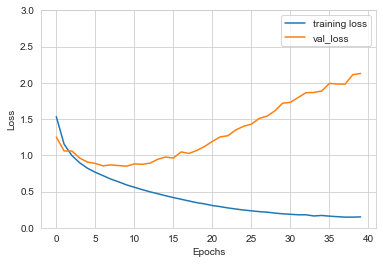

```python
plt.plot(history.history['loss'], label='training loss')
plt.plot(history.history['val_loss'],label='val_loss')
plt.xlabel('Epochs')
plt.ylabel('Loss')
plt.ylim([0, 3])

plt.legend(loc=0)
plt.show()
```

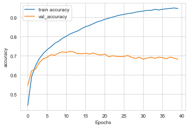

```python
plt.plot(history.history['accuracy'], label='train accuracy')
plt.plot(history.history['val_accuracy'],label='val_accuracy')
plt.xlabel('Epochs')
plt.ylabel('accuracy')
#plt.ylim([0, 2])

plt.legend(loc=0)
plt.show()
```

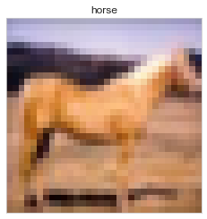

```python
plt.imshow(test_images[700])
plt.title(class_names[test_labels[700][0]])
plt.xticks([])
plt.yticks([])
plt.grid(False)
plt.show()
```

```python
model.predict(test_images[700].reshape(1,32,32,3))
```

```
array([[2.0929101e-01, 4.6588431e-11, 1.7687249e-08, 1.5984420e-04,
        1.1946053e-09, 1.1914708e-05, 2.9239232e-14, 7.9053730e-01,
        1.4998661e-09, 4.5963853e-12]], dtype=float32)
```

```python
model.predict(test_images[700].reshape(1,32,32,3)).round(3)
```

```
array([[0.209, 0.   , 0.   , 0.   , 0.   , 0.   , 0.   , 0.791, 0.   ,
        0.   ]], dtype=float32)
```

```python
np.argmax(model.predict(test_images[700].reshape(1,32,32,3)))
```

```
7
```

```python
class_names[np.argmax(model.predict(test_images[700].reshape(1,32,32,3)))]
```

```
'horse'
```